# FFTrees tree construction algorithms

Nathaniel Phillips

2018-09-15

FFTrees currently contains 4 different tree construction algorithms:

| Algorithm | Full Name | Reference |
| --- | --- | --- |
| ifan | Marginal Fan | Phillips, Neth, Gaissmaier, & Woike (2017) |
| dfan | Conditional Fan | Phillips et al. (2017) |
| zigzag | Zig-Zag | Martignon, Katsikopoulos, & Woike (2008) |
| max | Max | Martignon et al. (2008) |

## ifan

The default algorithm used to create trees `"ifan"` can be summarised in five steps.

5 Steps in growing FFTs using the ifan algorithm.

[output not shown]

## Example: Heart Disease

First, we’ll calculate a classification threshold for each cue using `cuerank()`:

```r
heartdisease.ca <- cuerank(formula = diagnosis ~.,
                           data = heartdisease)

# Print key results
heartdisease.ca[c("cue", "threshold", "direction", "bacc")]
```

```
##         cue            threshold direction  bacc
## 1       age                   55         > 0.635
## 2       sex                    0         > 0.630
## 3        cp                    a         = 0.759
## 4  trestbps                  140         > 0.558
## 5      chol                  242         > 0.568
## 6       fbs                    0         > 0.509
## 7   restecg hypertrophy,abnormal         = 0.588
## 8   thalach                  148        <= 0.695
## 9     exang                    0         > 0.703
## 10  oldpeak                  0.8         > 0.698
## 11    slope            flat,down         = 0.694
## 12       ca                    0         > 0.731
## 13     thal                rd,fd         = 0.760
```

Here, we see the best decision threshold for each cue that maximizes its balanced accuracy (`bacc`) when applied to the entire dataset (independently of other cues). For example, for the age cue, the best threshold is age > 55 which leads to a balanced accuracy of 0.63. In other words, if we only had the age cue, then the best decision is: “If age > 55, predict heart disease, otherwise, predict no heart disease”.

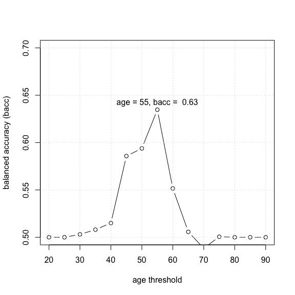

Plotting the balanced accuracy of each decision threshold for the age cue.

Next, the cues are ranked by their balanced accuracy. Let’s do that with the heart disease cues:

```r
# Rank heartdisease cues by balanced accuracy
heartdisease.ca <- heartdisease.ca[order(heartdisease.ca$bacc, decreasing = TRUE),]

# Print the key columns
heartdisease.ca[c("cue", "threshold", "direction", "bacc")]
```

```
##         cue            threshold direction  bacc
## 13     thal                rd,fd         = 0.760
## 3        cp                    a         = 0.759
## 12       ca                    0         > 0.731
## 9     exang                    0         > 0.703
## 10  oldpeak                  0.8         > 0.698
## 8   thalach                  148        <= 0.695
## 11    slope            flat,down         = 0.694
## 1       age                   55         > 0.635
## 2       sex                    0         > 0.630
## 7   restecg hypertrophy,abnormal         = 0.588
## 5      chol                  242         > 0.568
## 4  trestbps                  140         > 0.558
## 6       fbs                    0         > 0.509
```

We can also plot the cue accuracies in ROC space using the `showcues()` function:

```r
# Show the accuracy of cues in ROC space
showcues(cue.accuracies = heartdisease.ca)
```

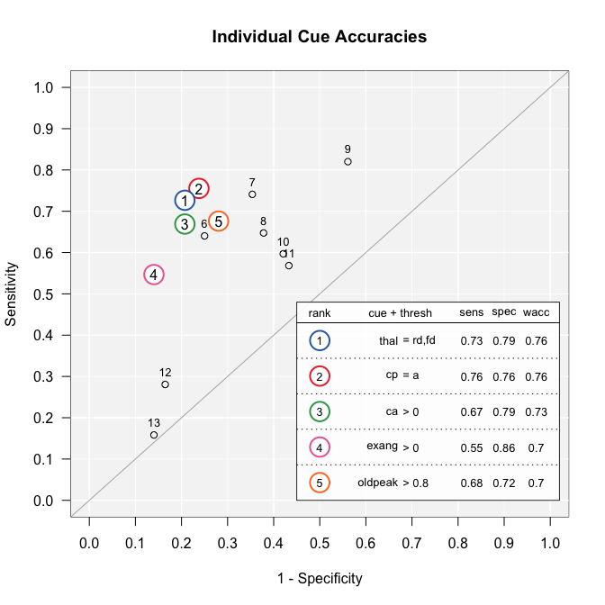

Cue accuracies for the heartdisease dataset. The top 5 cues in terms of balanced accuracy are highlighted.

Next, `grow.FFTrees()` will grow several trees from these cues using different exit structures:

```r
# Grow FFTs
heartdisease.ffts <- grow.FFTrees(formula = diagnosis ~.,
                                  data = heartdisease)

# Print the tree definitions
heartdisease.ffts$tree.definitions
```

```
##   tree nodes classes             cues directions  thresholds     exits
## 1    1     3   c;c;n       thal;cp;ca      =;=;>   rd,fd;a;0   1;0;0.5
## 2    2     4 c;c;n;n thal;cp;ca;exang    =;=;>;> rd,fd;a;0;0 1;0;1;0.5
## 3    3     3   c;c;n       thal;cp;ca      =;=;>   rd,fd;a;0   0;1;0.5
## 4    4     4 c;c;n;n thal;cp;ca;exang    =;=;>;> rd,fd;a;0;0 1;1;0;0.5
## 5    5     4 c;c;n;n thal;cp;ca;exang    =;=;>;> rd,fd;a;0;0 0;0;1;0.5
## 6    6     4 c;c;n;n thal;cp;ca;exang    =;=;>;> rd,fd;a;0;0 1;1;1;0.5
## 7    7     4 c;c;n;n thal;cp;ca;exang    =;=;>;> rd,fd;a;0;0 0;0;0;0.5
```

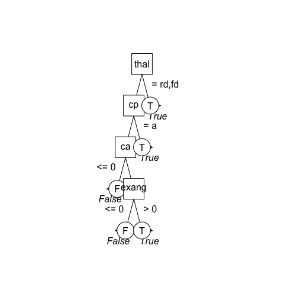

```r
# Create trees
heart.fft <- FFTrees(formula = diagnosis ~.,
                     data = heartdisease)

# Plot tree # 4
plot(heart.fft,
     stats = FALSE,    # Don't include statistics
     tree = 4)
```

## `"dfan"`

The `"dfan"` algorithm is identical to the `"ifan"` algorithm with one (important) exception: In `algorithm = "dfan"`, the thresholds and rankings of cues are recalculated for each level in the FFT conditioned on the exemplars that were *not* classified at higher leves in the tree. For example, in the `heartdisease` data, using `algorithm = "dfan"` would first classify some cases using the `thal` cue at the first level, and would then calculate new accuracies for the remaining cues on the remaining cases that were not yet classified. This algorithm is appropriate for datasets where cue validities systematically differ for different (and predictable) subsets of data. However, because it calculates cue thresholds for increasingly smaller samples of data as the tree grows, it is also, potentially, more prone to overfitting compared to `algorithm = "ifan"`

## Additional arguments

One can adjust the `"ifan"` and `"dfan"` algorithms in multiple ways. The most important arguments are `goal` and `goal.chase` which affect how thresholds are determined for each cue, and how cues are selected and ordered.

[output not shown]

## Specifying costs

If `goal = "cost"` and/or `goal.chase = "cost"`, the fan algorithms will try to minimize costs. One can specify two types of costs, `cost.cues`, the cost of using a cue to classify a case,, and `cost.outcomes` the cost of different outcomes.

`cost.cues` should be a data frame with two columns, one column giving the names of cues with costs, and one column giving the actual costs. For example, in the `heartdisease` dataset, cues have the following costs:

```r
heart.cue.cost <- list(age = 1,
                       sex = 1,
                       cp = 1,
                       trestbps = 1,
                       chol = 7.27,
                       fbs = 5.2,
                       restecg = 15.5,
                       thalach = 102.9,
                       exang = 87.3,
                       oldpeak = 87.3,
                       slope = 87.3,
                       ca = 100.9,
                       thal = 102.9)
```

`cost.outcome` should be a vector of length 4 indicating the cost of hits, false alarms, misses, and correct rejections reespectively. For example, if a false alarm has a cost of $500 and a miss has a cost of $1000, one could specify:

```r
# Specify the following costs for heart disease diagnosis:
# cost(Hit) = 0, cost(False Alarm) = 100, cost(Miss) = 200, cost(correct rejection) = 0

heart.cost.outcomes <- list(hi = 0, fa = 500, mi = 1000, cr = 0)
```

Here is an FFT that is built with the goal of maximizing balanced accuracy and *ignoring* these costs:

```r
heart.costA.fft <- FFTrees(formula = diagnosis ~.,
                          data = heartdisease,
                          cost.outcomes = heart.cost.outcomes,
                          cost.cues = heart.cue.cost,
                          goal = "bacc",
                          goal.chase = "bacc")
```

Let’s look at the performance of the best performing tree. The best tree has `bacc` = 0.812 and `cost` = 252

```r
summary(heart.costA.fft)
```

```
##        train test
## n    303.000   NA
## hi   118.000   NA
## mi    21.000   NA
## fa    37.000   NA
## cr   127.000   NA
## mcu    1.733   NA
## pci    0.876   NA
## cost 251.800   NA
## acc    0.809   NA
## bacc   0.812   NA
## sens   0.849   NA
## spec   0.774   NA
```

Now, we can build an FFT that tries to respect these costs:

```r
heart.costB.fft <- FFTrees(formula = diagnosis ~.,
                           data = heartdisease,
                           cost.outcomes = heart.cost.outcomes,
                           cost.cues = heart.cue.cost,
                           goal = "cost",
                           goal.chase = "cost")
```

Here’s it’s performance: it has a slightly lower balanced accuracy of `bacc = 0.76`, but a much lower cost of `cost = 160`

```r
summary(heart.costB.fft)
```

```
##        train test
## n    303.000   NA
## hi   133.000   NA
## mi     6.000   NA
## fa    72.000   NA
## cr    92.000   NA
## mcu    2.056   NA
## pci    0.853   NA
## cost 160.512   NA
## acc    0.743   NA
## bacc   0.759   NA
## sens   0.957   NA
## spec   0.561   NA
```

## `"max"` `"zigzag"`

The max and zigzag algorithms are described in Martignon et al. (2008).

### References

Martignon, L., Katsikopoulos, K. V., & Woike, J. K. (2008). Categorization with limited resources: A family of simple heuristics. *Journal of Mathematical Psychology*, *52*(6), 352–361.

Phillips, N., Neth, H., Gaissmaier, W., & Woike, J. (2017). *FFTrees: A toolbox to create, visualise, and implement fast-and-frugal decision trees*.